# IE582-Homework1

Hazal Hasret Yurdakul

18 October 2018

In this assignment, we are given the information about the soccer games played in English Premier League from August 2010 till today. Based on the statistical analyses of the match and odd information, we try to infer information about behaviours of odds. Before doing calculations, we must prepare the data that we are given.

Firstly, the match data and odds data are imported.

```r
# importing matches and odd details data
library(data.table)
matches_rawdata <- data.table(readRDS("matches.rds"))
odd_rawdata <- data.table(readRDS("odd_details.rds"))
```

Let’s see how the matches data looks like.

```r
head(matches_rawdata, n = 5)
```

```
##                                leagueId  matchId        home
## 1: df9b1196-e3cf-4cc7-9159-f236fe738215 KjF6FiA6   tottenham
## 2: df9b1196-e3cf-4cc7-9159-f236fe738215 ILVbJgQm aston villa
## 3: df9b1196-e3cf-4cc7-9159-f236fe738215 SGIEDVvJ      wolves
## 4: df9b1196-e3cf-4cc7-9159-f236fe738215 YwL5xFHJ      bolton
## 5: df9b1196-e3cf-4cc7-9159-f236fe738215 lQJAEBPC       wigan
##               away score       date   type
## 1: manchester city   0:0 1281789900 soccer
## 2:        west ham   3:0 1281798000 soccer
## 3:      stoke city   2:1 1281798000 soccer
## 4:          fulham   0:0 1281798000 soccer
## 5:       blackpool   0:4 1281798000 soccer
```

We should check the matches data whether the matchID column is distinct or not. As can be seen, the exactly same two matches have more than one row. One of them includes the match score but other one has just NA value in the score column. Therefore, we can omit those rows from matches data.

```r
# Is it distinct for all matches?
identical(length(unique(matches_rawdata$matchId)), length(matches_rawdata$matchId))
```

```
## [1] FALSE
```

```r
## Lets see what they are
check_match <- matches_rawdata[, .(count_match = length(unique(score))),
    by = matchId]
check_match[count_match == "2"]
```

```
##     matchId count_match
## 1: pK6po6ao           2
## 2: IkpEnbJh           2
```

```r
# We should remove these rows since they are exactly the same
# matches with the NA scores
matches_rawdata[matchId == ("pK6po6ao")]  ## see also for IkpEnbJh
```

```
##                                leagueId  matchId     home    away score
## 1: df9b1196-e3cf-4cc7-9159-f236fe738215 pK6po6ao west-ham chelsea   0:0
## 2: df9b1196-e3cf-4cc7-9159-f236fe738215 pK6po6ao west-ham chelsea    NA
##          date   type
## 1: 1537709400 soccer
## 2: 1537709400 soccer
```

```r
# remove the row where score is NA
matches_rawdata_ <- na.omit(matches_rawdata, score = NA)
# check again
identical(length(unique(matches_rawdata_$matchId)), length(matches_rawdata_$matchId))  #TRUE
```

```
## [1] TRUE
```

In the matches data,the data column is given as epoch time. Therefore,we should convert date and add as a match date column.

```r
matches_rawdata_[, "match_date"] <- as.POSIXct(matches_rawdata_$date,
    origin = "1970-01-01", "GMT")
```

Also,we can add total number of goals to the matches data.

```r
strsplit(matches_rawdata_$score, ":")
splitted <- t(sapply(matches_rawdata_$score, function(x) substring(x,
    first = c(1, 3), last = c(1, 3))))
matches_rawdata_[, "number_of_goals"] <- as.numeric(splitted[,
    1]) + as.numeric(splitted[, 2])
```

It seems okay.

```r
head(matches_rawdata_[, c(2, 5, 8)], 5)
```

```
##     matchId score          match_date
## 1: KjF6FiA6   0:0 2010-08-14 12:45:00
## 2: ILVbJgQm   3:0 2010-08-14 15:00:00
## 3: SGIEDVvJ   2:1 2010-08-14 15:00:00
## 4: YwL5xFHJ   0:0 2010-08-14 15:00:00
## 5: lQJAEBPC   0:4 2010-08-14 15:00:00
```

```r
matches_rawdata_[, "over_flag"] <- sapply(matches_rawdata_$number_of_goals,
    function(x) if (x >= 3) return(1) else if (x < 3) return(0))
```

For odds data, I checked whether there is a null date or not. Then, we can convert odd dates as we did in matches data. Also, we can add probability values which are calculates as 1/odd in this case.

```r
# convert epoch time to date
odd_rawdata[is.na(date) == 1]  # there is no null date
```

```
## Empty data.table (0 rows) of 7 cols: matchId,betType,oddtype,bookmaker,date,odd...
```

```r
odd_rawdata[, "odd_date"] <- as.POSIXct(odd_rawdata$date, origin = "1970-01-01",
    "GMT")
odd_rawdata[, "probability"] <- 1/odd_rawdata[, 6]
```

**Task 1**

**Part A**

In this task, we try to understand if bookmakers are good at deciding over/under 2.5 odds. Mainly, the data we are going to focus on is the one with totalhandicap=2.5 and betType=ou.

```r
odd_rawdata_ <- odd_rawdata[betType == "ou" & totalhandicap ==
    2.5]
```

Since we are interested in initial and final odds, we need to assign row number to find them.

```r
odd_rawdata_[, `:=`(row_number, rank(odd_date)), by = c("bookmaker",
    "matchId", "oddtype")]  #for initial odds
odd_over_under_initial <- odd_rawdata_[row_number == "1"]

odd_rawdata_[, `:=`(row_number, rank(-date)), by = c("bookmaker",
    "matchId", "oddtype")]  #for final odds
odd_over_under_final <- odd_rawdata_[row_number == "1"]
```

We are asked to select 5 bookmakers and plot the implied “over” probability average in a bin versus the fraction of games finished over for the corresponding bin.We can filter our data for each bookmaker.Betway is selected for illustration purposes.

```r
# get bookmaker's initial over under odds
x_bookmaker = "Betway"
bookmaker_over_under = odd_over_under_initial[bookmaker == x_bookmaker]

bookmaker = dcast(bookmaker_over_under, matchId ~ oddtype, value.var = "odd")
```

In order to reach match results in the odd data, we should merge these two data.

```r
# join odds with matches
merged_matches_fraction = merge(bookmaker, matches_rawdata_,
    by = "matchId")
```

Also, we should normalize the probabilities since they are not summed up to 1 due to bookmaker margin.

```r
# normalize
merged_matches_fraction[, `:=`(probOver, 1/over)]
merged_matches_fraction[, `:=`(probUnder, 1/under)]
merged_matches_fraction[, `:=`(totalProb, probOver + probUnder)]

merged_matches_fraction[, `:=`(probOver, probOver/totalProb)]
merged_matches_fraction[, `:=`(probUnder, probUnder/totalProb)]
```

Now, we should create bins for probabilities.The cutpoints can be generated with 0.05 intervals (i.e. (0.00,0.05], (0.05, 0.10], …, (0.95,1.00]).

```r
# bins
cutpoints = seq(0, 1, 0.05)
merged_matches_fraction[, `:=`(bins, cut(probOver, cutpoints))]
```

We can add years column into data.

```r
years = t(sapply(merged_matches_fraction$match_date, function(x) substring(x,
    first = c(1, 2, 3, 4), last = c(1, 2, 3, 4))))
merged_matches_fraction[, "years"] <- paste0(years[, 1], years[,
    2], years[, 3], years[, 4])
```

Let’s look at the results.

```r
result = merged_matches_fraction[, list(fraction_over_games = mean(as.numeric(over_flag)),
    over_prob_average_ = mean(probOver), .N), by = list(years,
    bins)]
result = result[order(years, bins)]
result
```

```
##     years       bins fraction_over_games over_prob_average_   N
##  1:  2011 (0.15,0.2]           0.0000000          0.1691843   1
##  2:  2011 (0.4,0.45]           0.4489796          0.4349731  49
##  3:  2011 (0.45,0.5]           0.5070423          0.4796622 142
##  4:  2011 (0.5,0.55]           0.6067416          0.5302800  89
##  5:  2011 (0.55,0.6]           0.6470588          0.5745888  51
##  6:  2011 (0.6,0.65]           0.7600000          0.6212784  25
##  7:  2011 (0.65,0.7]           0.6666667          0.6626506   3
##  8:  2011 (0.7,0.75]           0.0000000          0.7111111   1
##  9:  2012 (0.4,0.45]           0.2941176          0.4344272  17
## 10:  2012 (0.45,0.5]           0.5562914          0.4838011 151
## 11:  2012 (0.5,0.55]           0.5888889          0.5235963  90
## 12:  2012 (0.55,0.6]           0.4731183          0.5709023  93
## 13:  2012 (0.6,0.65]           0.6206897          0.6215128  29
## 14:  2012 (0.65,0.7]           0.3750000          0.6713499   8
```

[output cut: 49 more lines]

As you can see,some bins have small number of data especially between 0.15-0.45 and 0.65-0.85. Therefore, I prefer to merge these bins to get more meaningful results.

```r
# bins
cutpoints = c(0, 0.05, 0.1, 0.15, 0.45, 0.5, 0.55, 0.6, 0.65,
    0.8, 0.85, 0.9, 0.95, 1)
merged_matches_fraction[, `:=`(bins, cut(probOver, cutpoints))]
```

There are some small numbers in the last bin but they can stay as it is. If we merge the last bins also, the range would be too large.

```r
result = merged_matches_fraction[, list(fraction_over_games = mean(as.numeric(over_flag)),
    over_prob_average_ = mean(probOver), .N), by = list(bins,
    years)]
result = result[order(years, bins)]
result
```

```
##            bins years fraction_over_games over_prob_average_   N
##  1: (0.15,0.45]  2011           0.4400000          0.4296574  50
##  2:  (0.45,0.5]  2011           0.5070423          0.4796622 142
##  3:  (0.5,0.55]  2011           0.6067416          0.5302800  89
##  4:  (0.55,0.6]  2011           0.6470588          0.5745888  51
##  5:  (0.6,0.65]  2011           0.7600000          0.6212784  25
##  6:  (0.65,0.8]  2011           0.5000000          0.6747657   4
##  7: (0.15,0.45]  2012           0.2941176          0.4344272  17
##  8:  (0.45,0.5]  2012           0.5562914          0.4838011 151
##  9:  (0.5,0.55]  2012           0.5888889          0.5235963  90
## 10:  (0.55,0.6]  2012           0.4731183          0.5709023  93
## 11:  (0.6,0.65]  2012           0.6206897          0.6215128  29
## 12:  (0.65,0.8]  2012           0.5454545          0.6821939  11
## 13: (0.15,0.45]  2013           0.3703704          0.4337024  27
## 14:  (0.45,0.5]  2013           0.5147059          0.4829512 136
```

[output cut: 35 more lines]

We can plot the results for both initial and final odds.

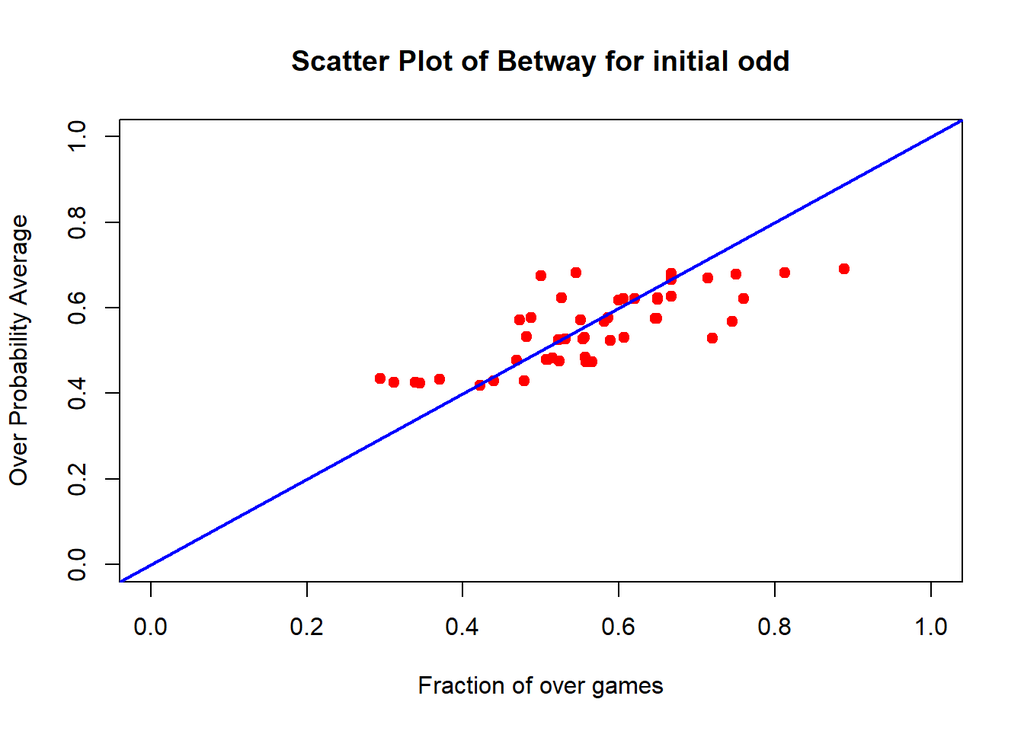

```r
# plot
plot(over_prob_average_ ~ fraction_over_games, pch = 20, cex = 1.5,
    col = "red", data = result, xlim = c(0, 1), ylim = c(0, 1),
    xlab = "Fraction of over games", ylab = "Over Probability Average",
    main = "Scatter Plot of Betway for initial odd")
# text(over_prob_average_~fraction_over_games,labels=bins,data=result,
# adj=c(1.2,0),cex=0.8,font=2)
abline(a = 0, b = 1, col = "blue", lwd = 2)
```

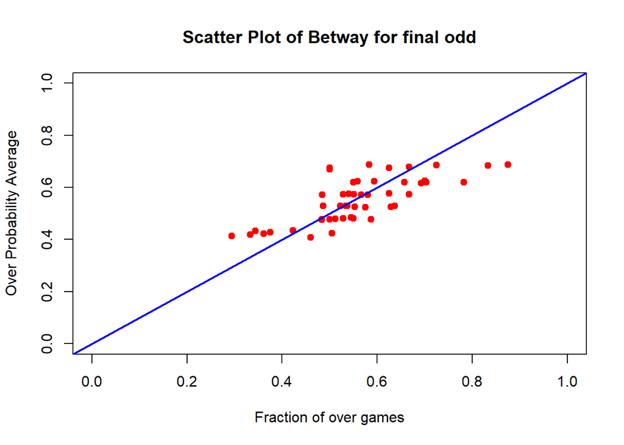

```r
# plot
plot(over_prob_average_ ~ fraction_over_games, pch = 20, cex = 1.5,
    col = "red", data = result, xlim = c(0, 1), ylim = c(0, 1),
    xlab = "Fraction of over games", ylab = "Over Probability Average",
    main = "Scatter Plot of Betway for final odd")
# text(over_prob_average_~fraction_over_games,labels=bins,data=result,
# adj=c(1.2,0),cex=0.8,font=2)
abline(a = 0, b = 1, col = "blue", lwd = 2)
```

Betway cannot be considered as successful bookmaker for low and high bins since the points look far away from the x=y line. However, in the middle, there are some correct guesses between 0.4 and 0.6 bins. In the final odd plot, the points are closer to the x=y line. Hence, the final bets for match results are better to guess the score.As you can see,the points(bins) are scattered for each year. Therefore, we do not whether Betway is successful for all the time in the middle bins.

We can do the same steps for remaining the 4 bookmakers such as bet365,William Hill,Unibet and bwin.

**Scatter Plot of Initial Odds**

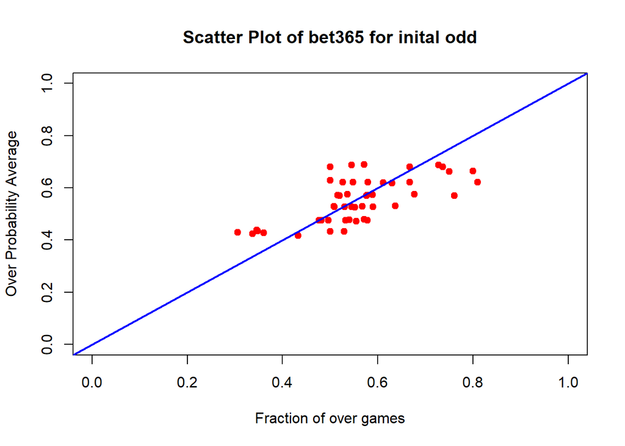

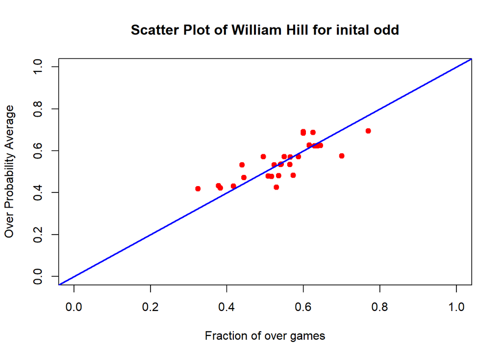

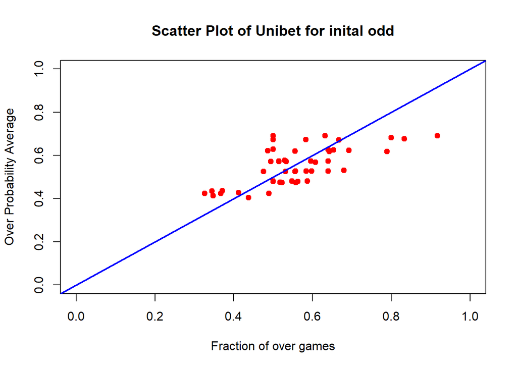

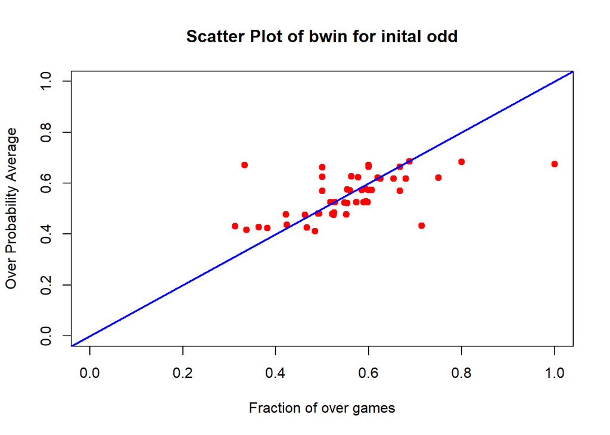

```r
# bookmakers
x_bookmaker = c("bet365", "William Hill", "Unibet", "bwin")
for (i in 1:4) {
    bookmaker_over_under = odd_over_under_initial[bookmaker ==
        x_bookmaker[i]]

    bookmaker = dcast(bookmaker_over_under, matchId ~ oddtype,
        value.var = "odd")

    # join odds with matches
    merged_matches_fraction = merge(bookmaker, matches_rawdata_,
        by = "matchId")

    # normalize
    merged_matches_fraction[, `:=`(probOver, 1/over)]
    merged_matches_fraction[, `:=`(probUnder, 1/under)]
    merged_matches_fraction[, `:=`(totalProb, probOver + probUnder)]

    merged_matches_fraction[, `:=`(probOver, probOver/totalProb)]
    merged_matches_fraction[, `:=`(probUnder, probUnder/totalProb)]

    # bins
    cutpoints = c(0, 0.05, 0.1, 0.15, 0.45, 0.5, 0.55, 0.6, 0.65,
        0.8, 0.85, 0.9, 0.95, 1)
    merged_matches_fraction[, `:=`(bins, cut(probOver, cutpoints))]
    years = t(sapply(merged_matches_fraction$match_date, function(x) substring(x,
        first = c(1, 2, 3, 4), last = c(1, 2, 3, 4))))
    merged_matches_fraction[, "years"] <- paste0(years[, 1],
        years[, 2], years[, 3], years[, 4])

    # lets look at the results
    result = merged_matches_fraction[, list(fraction_over_games = mean(as.numeric(over_flag)),
        over_prob_average_ = mean(probOver), .N), by = list(bins,
        years)]
    result = result[order(bins)]

    # plot
    plot(over_prob_average_ ~ fraction_over_games, pch = 20,
        cex = 1.5, col = "red", data = result, xlim = c(0, 1),
        ylim = c(0, 1), xlab = "Fraction of over games", ylab = "Over Probability Average",
        main = paste("Scatter Plot of", x_bookmaker[i], "for inital odd"))
    # text(over_prob_average_~fraction_over_games,labels=bins,data=result,
    # adj=c(1.2,0),cex=0.8,font=2)
    abline(a = 0, b = 1, col = "blue", lwd = 2)
}
```

**Scatter Plot of Final Odds**

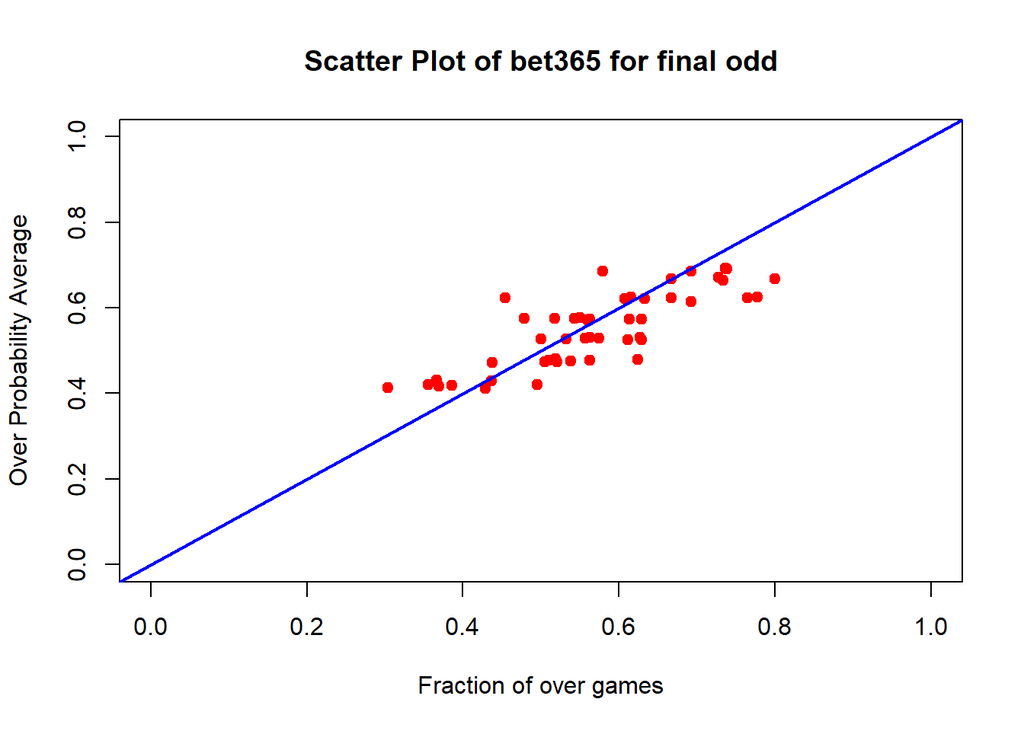

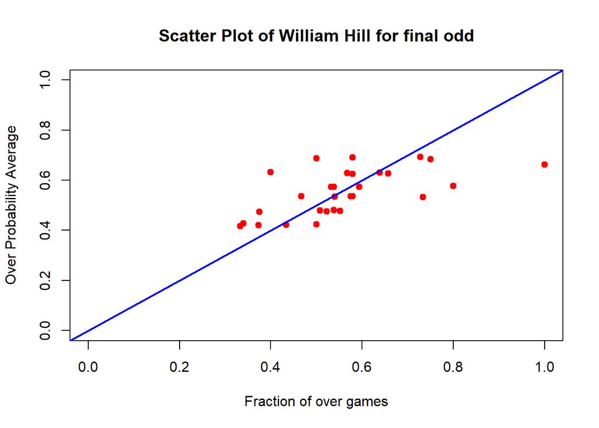

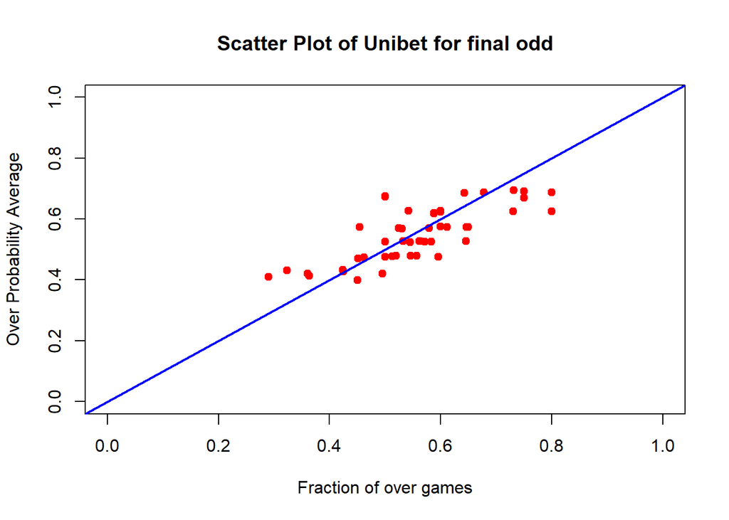

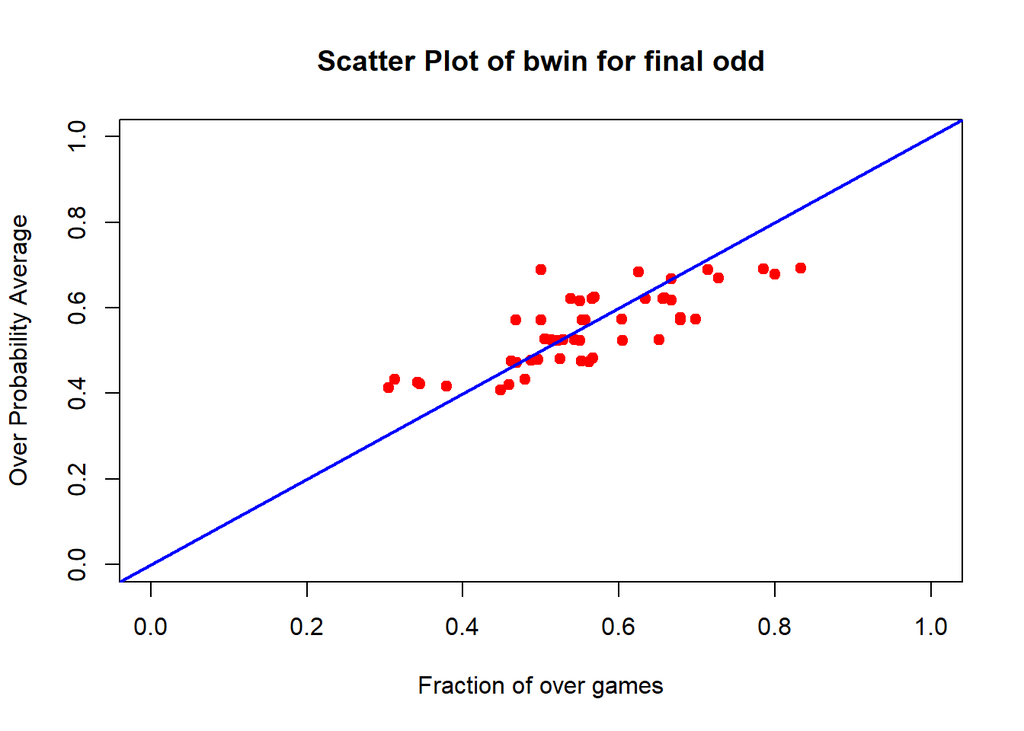

```r
# bookmakers
x_bookmaker = c("bet365", "William Hill", "Unibet", "bwin")
for (i in 1:4) {
    bookmaker_over_under = odd_over_under_final[bookmaker ==
        x_bookmaker[i]]

    bookmaker = dcast(bookmaker_over_under, matchId ~ oddtype,
        value.var = "odd")

    # join odds with matches
    merged_matches_fraction = merge(bookmaker, matches_rawdata_,
        by = "matchId")

    # normalize
    merged_matches_fraction[, `:=`(probOver, 1/over)]
    merged_matches_fraction[, `:=`(probUnder, 1/under)]
    merged_matches_fraction[, `:=`(totalProb, probOver + probUnder)]

    merged_matches_fraction[, `:=`(probOver, probOver/totalProb)]
    merged_matches_fraction[, `:=`(probUnder, probUnder/totalProb)]

    # bins
    cutpoints = c(0, 0.05, 0.1, 0.15, 0.45, 0.5, 0.55, 0.6, 0.65,
        0.8, 0.85, 0.9, 0.95, 1)
    merged_matches_fraction[, `:=`(bins, cut(probOver, cutpoints))]
    years = t(sapply(merged_matches_fraction$match_date, function(x) substring(x,
        first = c(1, 2, 3, 4), last = c(1, 2, 3, 4))))
    merged_matches_fraction[, "years"] <- paste0(years[, 1],
        years[, 2], years[, 3], years[, 4])

    # lets look at the results
    result = merged_matches_fraction[, list(fraction_over_games = mean(as.numeric(over_flag)),
        over_prob_average_ = mean(probOver), .N), by = list(bins,
        years)]
    result = result[order(bins)]

    # plot
    plot(over_prob_average_ ~ fraction_over_games, pch = 20,
        cex = 1.5, col = "red", data = result, xlim = c(0, 1),
        ylim = c(0, 1), xlab = "Fraction of over games", ylab = "Over Probability Average",
        main = paste("Scatter Plot of", x_bookmaker[i], "for final odd"))
    # text(over_prob_average_~fraction_over_games,labels=bins,data=result,
    # adj=c(1.2,0),cex=0.8,font=2)
    abline(a = 0, b = 1, col = "blue", lwd = 2)
}
```

In general, the final odds given by bookmakers are better than the initial odds. If odd is too small or too high, the match result may not be occurred as proposed. Therefore, the middle probabilities (0.4-0.6) have more chance to meet the target. Interestingly, William Hill seems to be better in guessing the results with initial odds. The reason is that it may change a lot the odd values since final odds look more separated from each other. Unibet and bwin are better compared to other bookmakers. Their final odds are guessed more correctly comparing with the inital odds.

**Part B**

We can make comparisons probabilistic average with empirical over in a yearly basis for bwin. The implied “over” probability average in a bin is calculated using final odd.

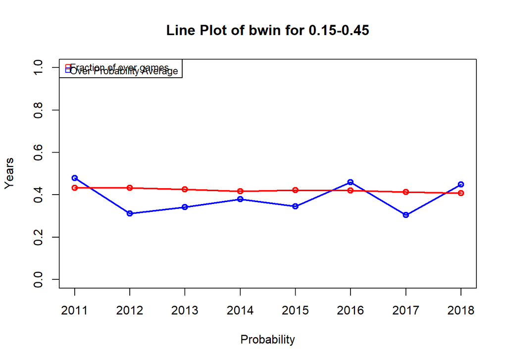

```r
plot(fraction_over_games ~ years, data = result_yearly[, c(1,
    2, 3)][bins == "(0.15,0.45]"], type = "o", lwd = 2, col = "blue",
    xlab = "Probability", ylab = "Years", main = paste("Line Plot of bwin for 0.15-0.45"),
    ylim = c(0, 1))
lines(over_prob_average_ ~ years, type = "o", col = "red", data = result_yearly[,
    c(1, 2, 4)][bins == "(0.15,0.45]"], lwd = 2)
legend("topleft", c("Fraction of over games", "Over Probability Average"),
    col = c(2, 4), pch = c(0, 0), cex = 0.8, xjust = 1, yjust = 1,
    x.intersp = 0.2, y.intersp = 0.3, bty = "o")
```

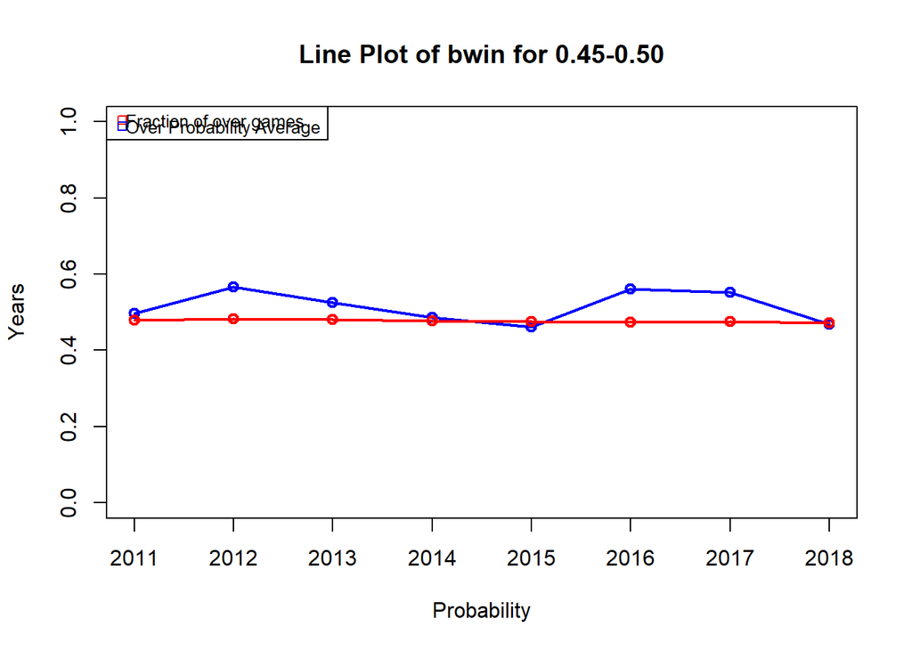

```r
plot(fraction_over_games ~ years, data = result_yearly[, c(1,
    2, 3)][bins == "(0.45,0.5]"], type = "o", lwd = 2, col = "blue",
    xlab = "Probability", ylab = "Years", main = paste("Line Plot of bwin for 0.45-0.50"),
    ylim = c(0, 1))
lines(over_prob_average_ ~ years, type = "o", col = "red", data = result_yearly[,
    c(1, 2, 4)][bins == "(0.45,0.5]"], lwd = 2)
legend("topleft", c("Fraction of over games", "Over Probability Average"),
    col = c(2, 4), pch = c(0, 0), cex = 0.8, xjust = 1, yjust = 1,
    x.intersp = 0.2, y.intersp = 0.3, bty = "o")
```

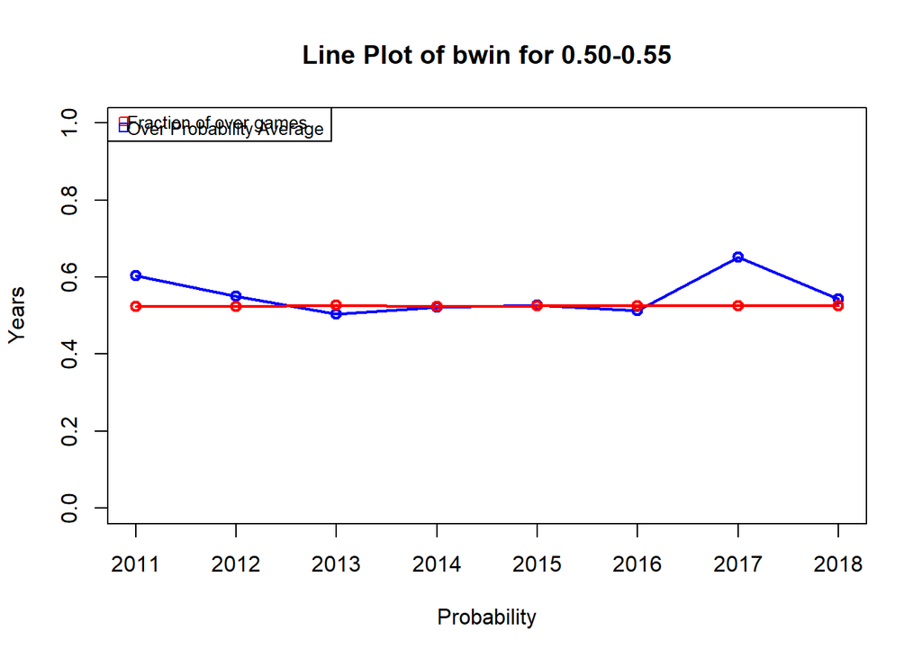

```r
plot(fraction_over_games ~ years, data = result_yearly[, c(1,
    2, 3)][bins == "(0.5,0.55]"], type = "o", lwd = 2, col = "blue",
    xlab = "Probability", ylab = "Years", main = paste("Line Plot of bwin for 0.50-0.55"),
    ylim = c(0, 1))
lines(over_prob_average_ ~ years, type = "o", col = "red", data = result_yearly[,
    c(1, 2, 4)][bins == "(0.5,0.55]"], lwd = 2)
legend("topleft", c("Fraction of over games", "Over Probability Average"),
    col = c(2, 4), pch = c(0, 0), cex = 0.8, xjust = 1, yjust = 1,
    x.intersp = 0.2, y.intersp = 0.3, bty = "o")
```

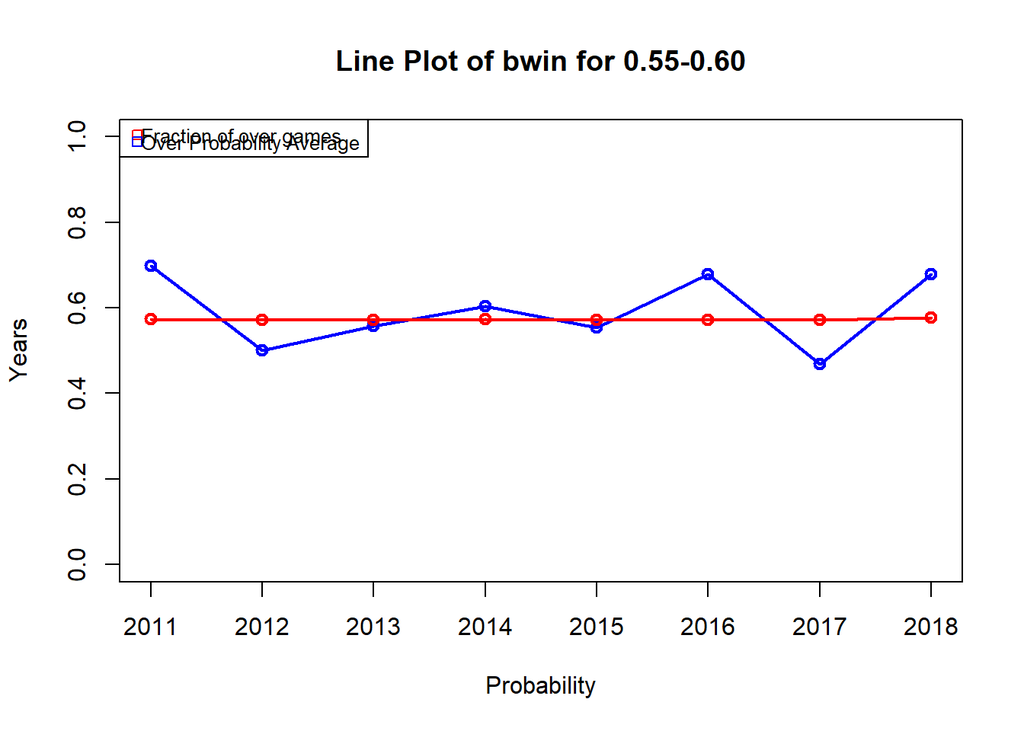

```r
plot(fraction_over_games ~ years, data = result_yearly[, c(1,
    2, 3)][bins == "(0.55,0.6]"], type = "o", lwd = 2, col = "blue",
    xlab = "Probability", ylab = "Years", main = paste("Line Plot of bwin for 0.55-0.60"),
    ylim = c(0, 1))
lines(over_prob_average_ ~ years, type = "o", col = "red", data = result_yearly[,
    c(1, 2, 4)][bins == "(0.55,0.6]"], lwd = 2)
legend("topleft", c("Fraction of over games", "Over Probability Average"),
    col = c(2, 4), pch = c(0, 0), cex = 0.8, xjust = 1, yjust = 1,
    x.intersp = 0.2, y.intersp = 0.3, bty = "o")
```

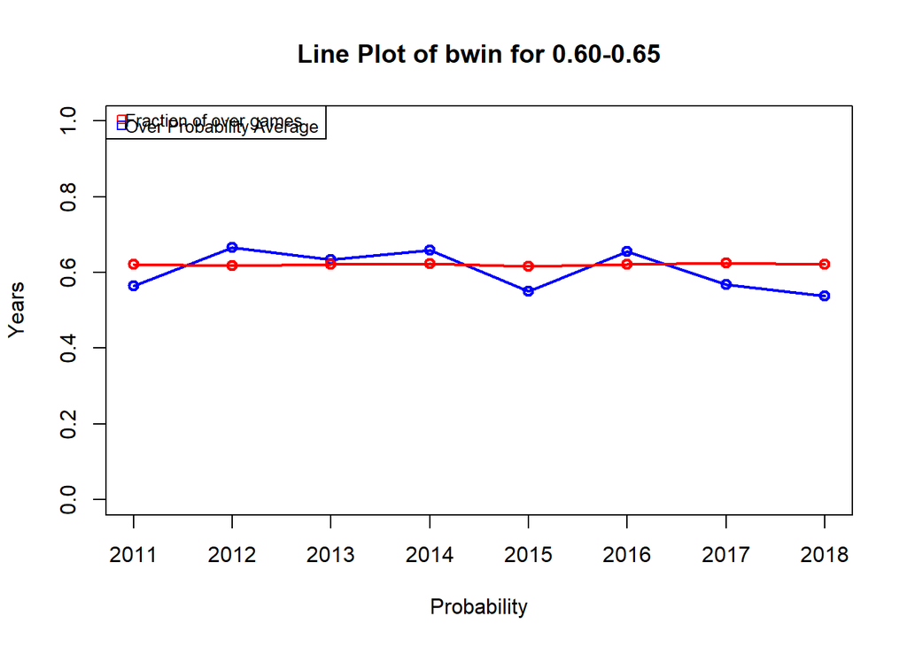

```r
plot(fraction_over_games ~ years, data = result_yearly[, c(1,
    2, 3)][bins == "(0.6,0.65]"], type = "o", lwd = 2, col = "blue",
    xlab = "Probability", ylab = "Years", main = paste("Line Plot of bwin for 0.60-0.65"),
    ylim = c(0, 1))
lines(over_prob_average_ ~ years, type = "o", col = "red", data = result_yearly[,
    c(1, 2, 4)][bins == "(0.6,0.65]"], lwd = 2)
legend("topleft", c("Fraction of over games", "Over Probability Average"),
    col = c(2, 4), pch = c(0, 0), cex = 0.8, xjust = 1, yjust = 1,
    x.intersp = 0.2, y.intersp = 0.3, bty = "o")
```

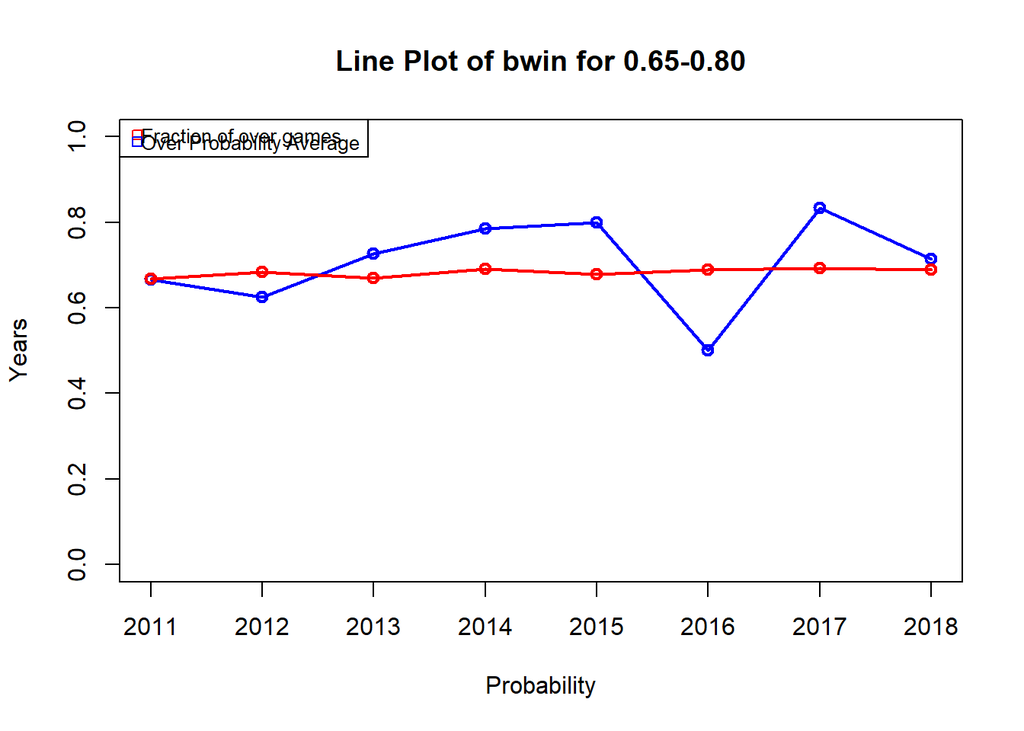

```r
plot(fraction_over_games ~ years, data = result_yearly[, c(1,
    2, 3)][bins == "(0.65,0.8]"], type = "o", lwd = 2, col = "blue",
    xlab = "Probability", ylab = "Years", main = paste("Line Plot of bwin for 0.65-0.80"),
    ylim = c(0, 1))
lines(over_prob_average_ ~ years, type = "o", col = "red", data = result_yearly[,
    c(1, 2, 4)][bins == "(0.65,0.8]"], lwd = 2)
legend("topleft", c("Fraction of over games", "Over Probability Average"),
    col = c(2, 4), pch = c(0, 0), cex = 0.8, xjust = 1, yjust = 1,
    x.intersp = 0.2, y.intersp = 0.3, bty = "o")
```

**TASK 2**

In this task,we try to observe the changes in the odds. We focus on the change of the odds for 1x2 bets. Also, we can choose the bookmaker as bwin again.

For visualization, I will try to create a 3D plot whose axes represent the odd types such as odd1, odd2 and oddX. In this way, we can see the all odd changes of the bookmaker in one plot. Also, I believe that change in any odd type is depending on the others. For example, if oddX is changed for a specific match, bookmaker may change the other odds such as odd1 and odd2 as well. Therefore, we should see the changes occurred by time. I think,we can see the replacement of the results in a 3D environment.

Before plotting the results, we should make some arrangements. The data that we are given includes the change in odds row by row. However, we need the current odd’s distribution in one row. In other words, suppose that bookmaker gave the odd’s values 1.5,1.35, and 1.65 for odd1,oddX and odd2 respectively. After that, the oddX is changed. Now, the odd values become 1.5,1.4, and 1.65 for odd1,oddX and odd2. Therefore, we should prepare our data in this structure.

Let’s generate the raw data.

```r
odds_ordered = odd_rawdata[betType == "1x2" & bookmaker == "bwin"][order(matchId,
    date)]
oddtype_data = odds_ordered[, c(1, 5, 3, 6)]
head(oddtype_data, 5)
```

```
##     matchId       date oddtype  odd
## 1: 004f4ING 1421001060    odd1 1.62
## 2: 004f4ING 1421001060    odd2 5.00
## 3: 004f4ING 1421001060    oddX 4.00
## 4: 004f4ING 1422806280    odd1 1.67
## 5: 004f4ING 1422806280    odd2 5.50
```

odd1, odd2 and oddX columns are generated.

```r
library(dplyr)
oddtype_data_1 = oddtype_data %>% select(matchId, date) %>% mutate(odd1 = case_when(oddtype_data$oddtype ==
    "odd1" ~ oddtype_data$odd))

oddtype_data_2 = oddtype_data_1 %>% select(matchId, date, odd1) %>%
    mutate(odd2 = case_when(oddtype_data$oddtype == "odd2" ~
        oddtype_data$odd))

oddtype_data_3 = oddtype_data_2 %>% select(matchId, date, odd1,
    odd2) %>% mutate(oddX = case_when(oddtype_data$oddtype ==
    "oddX" ~ oddtype_data$odd))
# make NA as 0
oddtype_data_3[is.na(oddtype_data_3)] <- 0
```

As you can see, we have multiple rows for each match date. The 0’s in columns mean that there is no change in the odd. If there is value in the corresponding odd, then a value is associated with it.

```r
head(oddtype_data_3, 5)
```

```
##    matchId       date odd1 odd2 oddX
## 1 004f4ING 1421001060 1.62  0.0    0
## 2 004f4ING 1421001060 0.00  5.0    0
## 3 004f4ING 1421001060 0.00  0.0    4
## 4 004f4ING 1422806280 1.67  0.0    0
## 5 004f4ING 1422806280 0.00  5.5    0
```

Now, we can summed up the rows for each specific matchId and date. Also, in the data, there is no 2 changes in a odd type for a specific date. Each date has a change at most 3 because of we have 3 odd types.

```r
oddtype_data_4 = oddtype_data_3 %>% group_by(matchId, date) %>%
    summarise(odd1 = sum(odd1), odd2 = sum(odd2), oddX = sum(oddX))

oddtype_data_4 = data.table(oddtype_data_4)

# the loops are for the zero values in the data. It basically
# replace the zero values with the older value since there is
# no change in there.

for (j in 1:length(oddtype_data_4$matchId)) {
    if (oddtype_data_4$odd1[j] == 0) {
        oddtype_data_4$odd1[j] <- oddtype_data_4$odd1[j - 1]
    } else oddtype_data_4$odd1[j] <- oddtype_data_4$odd1[j]
}


for (j in 1:length(oddtype_data_4$matchId)) {
    if (oddtype_data_4$odd2[j] == 0) {
        oddtype_data_4$odd2[j] <- oddtype_data_4$odd2[j - 1]
    } else oddtype_data_4$odd2[j] <- oddtype_data_4$odd2[j]
}

for (j in 1:length(oddtype_data_4$matchId)) {
    if (oddtype_data_4$oddX[j] == 0) {
        oddtype_data_4$oddX[j] <- oddtype_data_4$oddX[j - 1]
    } else oddtype_data_4$oddX[j] <- oddtype_data_4$oddX[j]
}
```

After summing, we can see the odd values for each time. When a value of oddtype is changed, the date and new odd values are given under that row.

```r
head(oddtype_data_4, 5)
```

```
##     matchId       date odd1 odd2 oddX
## 1: 004f4ING 1421001060 1.62  5.0  4.0
## 2: 004f4ING 1422806280 1.67  5.5  3.9
## 3: 02oVDuv1 1508332680 2.10  3.5  3.2
## 4: 02oVDuv1 1509677760 2.10  3.5  3.5
## 5: 02oVDuv1 1509804900 1.83  4.6  3.5
```

We can plot the our data and see how it looks like.

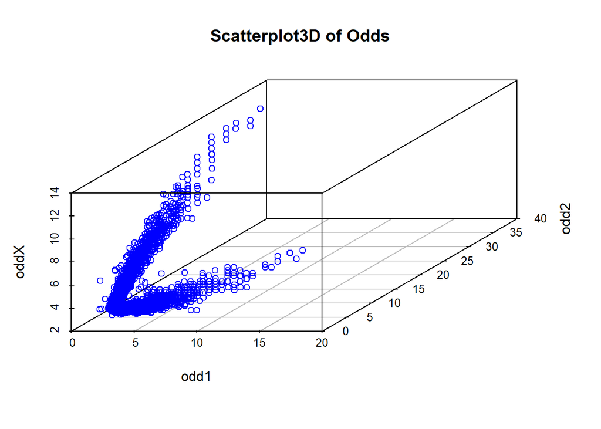

```r
library(scatterplot3d)
scatterplot3d(oddtype_data_4[, c(3, 4, 5)], angle = 55, color = "blue",
    main = "Scatterplot3D of Odds")
```

As you can see, there is a V shape in the corner of odd1 and oddX. Most of the odds are changed in that region. Also, there are some variations between odds since some points looks far away from each other.

In order to see the changes clearly, we can look the difference between initial and final odd values of each odd type for each matchID.Therefore, we can see how difference is distributed.

```r
oddtype_data_4[, `:=`(row_number, rank(date)), by = c("matchId")]  #for initial odds
oddtype_initial <- oddtype_data_4[row_number == "1"]

oddtype_data_4[, `:=`(row_number, rank(-date)), by = c("matchId")]  #for final odds
oddtype_final <- oddtype_data_4[row_number == "1"]

oddtype_initial = oddtype_initial[, c(1, 3, 4, 5)]
oddtype_final = oddtype_final[, c(1, 3, 4, 5)]
merged_oddtype = merge(oddtype_final, oddtype_initial, by = "matchId")  ##change

merged_oddtype[, "odd1_difference"] <- merged_oddtype[, 2] -
    merged_oddtype[, 5]
merged_oddtype[, "odd2_difference"] <- merged_oddtype[, 3] -
    merged_oddtype[, 6]
merged_oddtype[, "oddX_difference"] <- merged_oddtype[, 4] -
    merged_oddtype[, 7]

oddtype_final_difference = merged_oddtype[, c(1, 8, 9, 10)]
head(oddtype_final_difference, 5)
```

```
##     matchId odd1_difference odd2_difference oddX_difference
## 1: 004f4ING            0.05             0.5           -0.10
## 2: 02oVDuv1           -0.27             1.1            0.30
## 3: 04PCiQzK           -0.07             0.5            0.50
## 4: 04vrPwsg            0.05             0.3           -0.10
## 5: 04zko0D5            0.00             3.5           -0.75
```

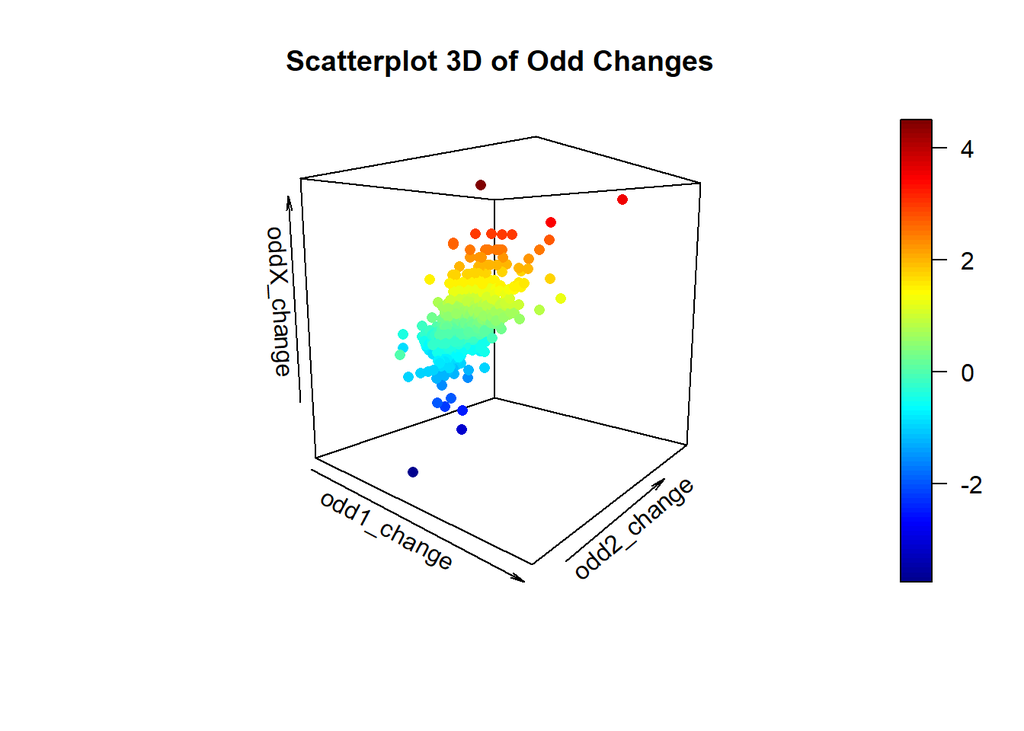

```r
library(plot3D)
scatter3D(oddtype_final_difference$odd1_difference, oddtype_final_difference$odd2_difference,
    oddtype_final_difference$oddX_difference, pch = 16, theta = 40,
    phi = 8, xlab = "odd1_change", ylab = "odd2_change", zlab = "oddX_change",
    main = "Scatterplot 3D of Odd Changes")
```